# Risk Factor Analysis

## Outcome Variable

**Outcome Variable:** wasted

## Predictor Variables

**Intervention Variable:** hdlvry

**Adjustment Set:**

- arm
- sex
- W_mage
- meducyrs
- feducyrs
- hhwealth_quart
- hfoodsec
- W_nrooms
- brthmon
- impfloor
- impsan
- safeh20
- delta_W_mage
- delta_meducyrs
- delta_feducyrs
- delta_hhwealth_quart
- delta_hfoodsec
- delta_W_nrooms
- delta_brthmon
- delta_impfloor
- delta_impsan
- delta_safeh20

## Stratifying Variables

The analysis was stratified on these variable(s):

- agecat
- studyid
- country

## Data Summary

| agecat | studyid | country | hdlvry | wasted | n_cell | n |
| --- | --- | --- | --- | --- | --- | --- |
| Birth | ki1000108-CMC-V-BCS-2002 | INDIA | 0 | 0 | 74 | 88 |
| Birth | ki1000108-CMC-V-BCS-2002 | INDIA | 0 | 1 | 12 | 88 |
| Birth | ki1000108-CMC-V-BCS-2002 | INDIA | 1 | 0 | 0 | 88 |
| Birth | ki1000108-CMC-V-BCS-2002 | INDIA | 1 | 1 | 2 | 88 |
| Birth | ki1000108-IRC | INDIA | 0 | 0 | 249 | 343 |
| Birth | ki1000108-IRC | INDIA | 0 | 1 | 88 | 343 |
| Birth | ki1000108-IRC | INDIA | 1 | 0 | 2 | 343 |
| Birth | ki1000108-IRC | INDIA | 1 | 1 | 4 | 343 |
| Birth | ki1000109-EE | PAKISTAN | 0 | 0 | 2 | 2 |
| Birth | ki1000109-EE | PAKISTAN | 0 | 1 | 0 | 2 |
| Birth | ki1000109-EE | PAKISTAN | 1 | 0 | 0 | 2 |
| Birth | ki1000109-EE | PAKISTAN | 1 | 1 | 0 | 2 |
| Birth | ki1000304b-SAS-CompFeed | INDIA | 0 | 0 | 5 | 160 |
| Birth | ki1000304b-SAS-CompFeed | INDIA | 0 | 1 | 1 | 160 |
| Birth | ki1000304b-SAS-CompFeed | INDIA | 1 | 0 | 144 | 160 |
| Birth | ki1000304b-SAS-CompFeed | INDIA | 1 | 1 | 10 | 160 |
| Birth | ki1017093c-NIH-Crypto | BANGLADESH | 0 | 0 | 16 | 23 |
| Birth | ki1017093c-NIH-Crypto | BANGLADESH | 0 | 1 | 3 | 23 |
| Birth | ki1017093c-NIH-Crypto | BANGLADESH | 1 | 0 | 4 | 23 |
| Birth | ki1017093c-NIH-Crypto | BANGLADESH | 1 | 1 | 0 | 23 |
| Birth | ki1135781-COHORTS | INDIA | 0 | 0 | 2284 | 4389 |
| Birth | ki1135781-COHORTS | INDIA | 0 | 1 | 479 | 4389 |
| Birth | ki1135781-COHORTS | INDIA | 1 | 0 | 1344 | 4389 |
| Birth | ki1135781-COHORTS | INDIA | 1 | 1 | 282 | 4389 |
| Birth | kiGH5241-JiVitA-3 | BANGLADESH | 0 | 0 | 16 | 526 |
| Birth | kiGH5241-JiVitA-3 | BANGLADESH | 0 | 1 | 0 | 526 |
| Birth | kiGH5241-JiVitA-3 | BANGLADESH | 1 | 0 | 452 | 526 |
| Birth | kiGH5241-JiVitA-3 | BANGLADESH | 1 | 1 | 58 | 526 |
| Birth | kiGH5241-JiVitA-4 | BANGLADESH | 0 | 0 | 82 | 1362 |
| Birth | kiGH5241-JiVitA-4 | BANGLADESH | 0 | 1 | 4 | 1362 |

[output cut: 86 more lines]

The following strata were considered:

- agecat: 24 months, studyid: ki1000108-CMC-V-BCS-2002, country: INDIA
- agecat: 24 months, studyid: ki1000108-IRC, country: INDIA
- agecat: 24 months, studyid: ki1017093b-PROVIDE, country: BANGLADESH
- agecat: 24 months, studyid: ki1017093c-NIH-Crypto, country: BANGLADESH
- agecat: 24 months, studyid: ki1066203-TanzaniaChild2, country: TANZANIA, UNITED REPUBLIC OF
- agecat: 24 months, studyid: ki1113344-GMS-Nepal, country: NEPAL
- agecat: 24 months, studyid: ki1135781-COHORTS, country: INDIA
- agecat: 24 months, studyid: kiGH5241-JiVitA-3, country: BANGLADESH
- agecat: 24 months, studyid: kiGH5241-JiVitA-4, country: BANGLADESH
- agecat: 6 months, studyid: ki1000108-CMC-V-BCS-2002, country: INDIA
- agecat: 6 months, studyid: ki1000108-IRC, country: INDIA
- agecat: 6 months, studyid: ki1000109-EE, country: PAKISTAN
- agecat: 6 months, studyid: ki1000304b-SAS-CompFeed, country: INDIA
- agecat: 6 months, studyid: ki1000304b-SAS-FoodSuppl, country: INDIA
- agecat: 6 months, studyid: ki1017093b-PROVIDE, country: BANGLADESH
- agecat: 6 months, studyid: ki1017093c-NIH-Crypto, country: BANGLADESH
- agecat: 6 months, studyid: ki1066203-TanzaniaChild2, country: TANZANIA, UNITED REPUBLIC OF
- agecat: 6 months, studyid: ki1113344-GMS-Nepal, country: NEPAL
- agecat: 6 months, studyid: ki1135781-COHORTS, country: INDIA
- agecat: 6 months, studyid: kiGH5241-JiVitA-3, country: BANGLADESH
- agecat: 6 months, studyid: kiGH5241-JiVitA-4, country: BANGLADESH
- agecat: Birth, studyid: ki1000108-CMC-V-BCS-2002, country: INDIA
- agecat: Birth, studyid: ki1000108-IRC, country: INDIA
- agecat: Birth, studyid: ki1000109-EE, country: PAKISTAN
- agecat: Birth, studyid: ki1000304b-SAS-CompFeed, country: INDIA
- agecat: Birth, studyid: ki1017093c-NIH-Crypto, country: BANGLADESH
- agecat: Birth, studyid: ki1135781-COHORTS, country: INDIA
- agecat: Birth, studyid: kiGH5241-JiVitA-3, country: BANGLADESH
- agecat: Birth, studyid: kiGH5241-JiVitA-4, country: BANGLADESH

### Dropped Strata

Some strata were dropped due to rare outcomes:

- agecat: Birth, studyid: ki1000108-CMC-V-BCS-2002, country: INDIA
- agecat: Birth, studyid: ki1000108-IRC, country: INDIA
- agecat: Birth, studyid: ki1000109-EE, country: PAKISTAN
- agecat: Birth, studyid: ki1000304b-SAS-CompFeed, country: INDIA
- agecat: Birth, studyid: ki1017093c-NIH-Crypto, country: BANGLADESH
- agecat: Birth, studyid: kiGH5241-JiVitA-3, country: BANGLADESH
- agecat: Birth, studyid: kiGH5241-JiVitA-4, country: BANGLADESH
- agecat: 6 months, studyid: ki1000108-CMC-V-BCS-2002, country: INDIA
- agecat: 6 months, studyid: ki1000108-IRC, country: INDIA
- agecat: 6 months, studyid: ki1017093b-PROVIDE, country: BANGLADESH
- agecat: 6 months, studyid: ki1066203-TanzaniaChild2, country: TANZANIA, UNITED REPUBLIC OF
- agecat: 6 months, studyid: kiGH5241-JiVitA-3, country: BANGLADESH
- agecat: 24 months, studyid: ki1000108-CMC-V-BCS-2002, country: INDIA
- agecat: 24 months, studyid: ki1000108-IRC, country: INDIA
- agecat: 24 months, studyid: ki1066203-TanzaniaChild2, country: TANZANIA, UNITED REPUBLIC OF

## Methods Detail

We’re interested in the causal parameters $E[Y_a]$ for all values of $a \in \mathcal{A}$. These parameters represent the mean outcome if, possibly contrary to fact, we intervened to set all units to have $A=a$. Under the randomization and positivity assumptions, these are identified by the statistical parameters $\psi_a=E_W[E_{Y|A,W}(Y|A=a,W)]$. In addition, we’re interested in the mean of $Y$, $E[Y]$ under no intervention (the observed mean). We will estimate these parameters by using SuperLearner to fit the relevant likelihood factors – $E_{Y|A,W}(Y|A=a,W)$ and $p(A=a|W)$, and then updating our likelihood fit using a joint TMLE.

For unadjusted analyses ($W=\{\}$), initial likelihoods were estimated using Lrnr_glm to estimate the simple $E(Y|A)$ and Lrnr_mean to estimate $p(A)$. For adjusted analyses, a small library containing Lrnr_glmnet, Lrnr_xgboost, and Lrnr_mean was used.

Having estimated these parameters, we will then use the delta method to estimate relative risks and attributable risks relative to a prespecified baseline level of $A$.

# Results Detail

## Results Plots

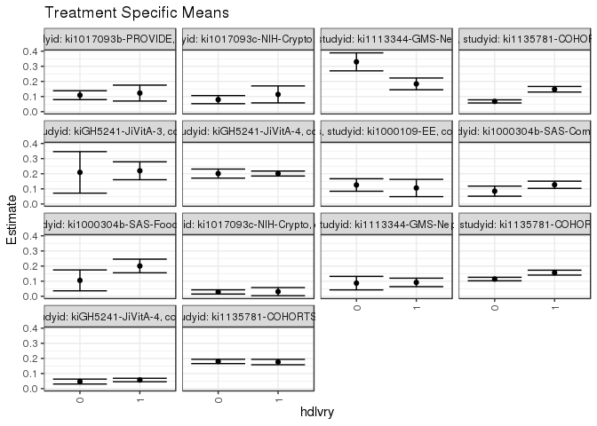

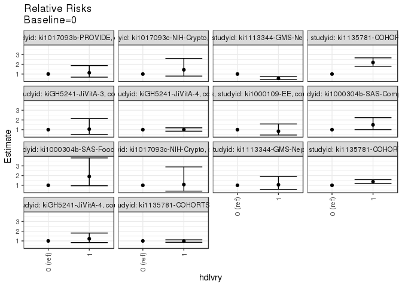

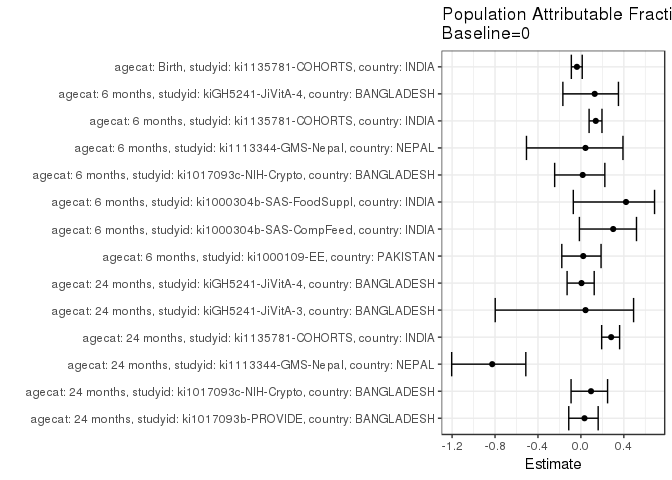

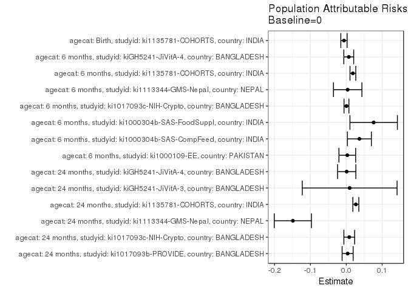

## Results Table

### Parameter: TSM

| agecat | studyid | country | intervention_level | baseline_level | estimate | ci_lower | ci_upper |
| --- | --- | --- | --- | --- | --- | --- | --- |
| Birth | ki1135781-COHORTS | INDIA | 0 | NA | 0.1798256 | 0.1655833 | 0.1940679 |
| Birth | ki1135781-COHORTS | INDIA | 1 | NA | 0.1759777 | 0.1581730 | 0.1937825 |
| 6 months | ki1000109-EE | PAKISTAN | 0 | NA | 0.1255333 | 0.0841574 | 0.1669093 |
| 6 months | ki1000109-EE | PAKISTAN | 1 | NA | 0.1056789 | 0.0486214 | 0.1627365 |
| 6 months | ki1000304b-SAS-CompFeed | INDIA | 0 | NA | 0.0848194 | 0.0514590 | 0.1181798 |
| 6 months | ki1000304b-SAS-CompFeed | INDIA | 1 | NA | 0.1270434 | 0.1032523 | 0.1508344 |
| 6 months | ki1000304b-SAS-FoodSuppl | INDIA | 0 | NA | 0.1052632 | 0.0361757 | 0.1743506 |
| 6 months | ki1000304b-SAS-FoodSuppl | INDIA | 1 | NA | 0.2006579 | 0.1555785 | 0.2457373 |
| 6 months | ki1017093c-NIH-Crypto | BANGLADESH | 0 | NA | 0.0288809 | 0.0149256 | 0.0428361 |
| 6 months | ki1017093c-NIH-Crypto | BANGLADESH | 1 | NA | 0.0310559 | 0.0042420 | 0.0578698 |
| 6 months | ki1113344-GMS-Nepal | NEPAL | 0 | NA | 0.0871883 | 0.0425337 | 0.1318429 |
| 6 months | ki1113344-GMS-Nepal | NEPAL | 1 | NA | 0.0919032 | 0.0638560 | 0.1199504 |
| 6 months | ki1135781-COHORTS | INDIA | 0 | NA | 0.1141639 | 0.1025970 | 0.1257307 |
| 6 months | ki1135781-COHORTS | INDIA | 1 | NA | 0.1564322 | 0.1401853 | 0.1726791 |
| 6 months | kiGH5241-JiVitA-4 | BANGLADESH | 0 | NA | 0.0468417 | 0.0306369 | 0.0630466 |
| 6 months | kiGH5241-JiVitA-4 | BANGLADESH | 1 | NA | 0.0573159 | 0.0459568 | 0.0686749 |
| 24 months | ki1017093b-PROVIDE | BANGLADESH | 0 | NA | 0.1086896 | 0.0793367 | 0.1380425 |
| 24 months | ki1017093b-PROVIDE | BANGLADESH | 1 | NA | 0.1226685 | 0.0701275 | 0.1752096 |
| 24 months | ki1017093c-NIH-Crypto | BANGLADESH | 0 | NA | 0.0792912 | 0.0524921 | 0.1060903 |
| 24 months | ki1017093c-NIH-Crypto | BANGLADESH | 1 | NA | 0.1139374 | 0.0578978 | 0.1699771 |
| 24 months | ki1113344-GMS-Nepal | NEPAL | 0 | NA | 0.3291831 | 0.2697709 | 0.3885953 |
| 24 months | ki1113344-GMS-Nepal | NEPAL | 1 | NA | 0.1835687 | 0.1447460 | 0.2223914 |
| 24 months | ki1135781-COHORTS | INDIA | 0 | NA | 0.0676840 | 0.0572644 | 0.0781036 |
| 24 months | ki1135781-COHORTS | INDIA | 1 | NA | 0.1480599 | 0.1297183 | 0.1664016 |
| 24 months | kiGH5241-JiVitA-3 | BANGLADESH | 0 | NA | 0.2089552 | 0.0716538 | 0.3462566 |
| 24 months | kiGH5241-JiVitA-3 | BANGLADESH | 1 | NA | 0.2196078 | 0.1604795 | 0.2787362 |
| 24 months | kiGH5241-JiVitA-4 | BANGLADESH | 0 | NA | 0.2009681 | 0.1710133 | 0.2309229 |
| 24 months | kiGH5241-JiVitA-4 | BANGLADESH | 1 | NA | 0.2013312 | 0.1849215 | 0.2177409 |

### Parameter: E(Y)

| agecat | studyid | country | intervention_level | baseline_level | estimate | ci_lower | ci_upper |
| --- | --- | --- | --- | --- | --- | --- | --- |
| Birth | ki1135781-COHORTS | INDIA | NA | NA | 0.1733880 | 0.1621865 | 0.1845895 |
| 6 months | ki1000109-EE | PAKISTAN | NA | NA | 0.1283422 | 0.0943991 | 0.1622853 |
| 6 months | ki1000304b-SAS-CompFeed | INDIA | NA | NA | 0.1213235 | 0.0974115 | 0.1452356 |
| 6 months | ki1000304b-SAS-FoodSuppl | INDIA | NA | NA | 0.1815789 | 0.1427684 | 0.2203895 |
| 6 months | ki1017093c-NIH-Crypto | BANGLADESH | NA | NA | 0.0293706 | 0.0169860 | 0.0417552 |
| 6 months | ki1113344-GMS-Nepal | NEPAL | NA | NA | 0.0910816 | 0.0664930 | 0.1156701 |
| 6 months | ki1135781-COHORTS | INDIA | NA | NA | 0.1325096 | 0.1228094 | 0.1422097 |
| 6 months | kiGH5241-JiVitA-4 | BANGLADESH | NA | NA | 0.0537528 | 0.0440673 | 0.0634383 |
| 24 months | ki1017093b-PROVIDE | BANGLADESH | NA | NA | 0.1124567 | 0.0866788 | 0.1382347 |
| 24 months | ki1017093c-NIH-Crypto | BANGLADESH | NA | NA | 0.0875486 | 0.0630907 | 0.1120065 |
| 24 months | ki1113344-GMS-Nepal | NEPAL | NA | NA | 0.1802575 | 0.1453188 | 0.2151962 |
| 24 months | ki1135781-COHORTS | INDIA | NA | NA | 0.0942542 | 0.0846183 | 0.1038901 |
| 24 months | kiGH5241-JiVitA-3 | BANGLADESH | NA | NA | 0.2183709 | 0.1637859 | 0.2729559 |
| 24 months | kiGH5241-JiVitA-4 | BANGLADESH | NA | NA | 0.2021063 | 0.1874789 | 0.2167337 |

### Parameter: RR

| agecat | studyid | country | intervention_level | baseline_level | estimate | ci_lower | ci_upper |
| --- | --- | --- | --- | --- | --- | --- | --- |
| Birth | ki1135781-COHORTS | INDIA | 0 | 0 | 1.0000000 | 1.0000000 | 1.0000000 |
| Birth | ki1135781-COHORTS | INDIA | 1 | 0 | 0.9786024 | 0.8609052 | 1.1123904 |
| 6 months | ki1000109-EE | PAKISTAN | 0 | 0 | 1.0000000 | 1.0000000 | 1.0000000 |
| 6 months | ki1000109-EE | PAKISTAN | 1 | 0 | 0.8418396 | 0.4468674 | 1.5859155 |
| 6 months | ki1000304b-SAS-CompFeed | INDIA | 0 | 0 | 1.0000000 | 1.0000000 | 1.0000000 |
| 6 months | ki1000304b-SAS-CompFeed | INDIA | 1 | 0 | 1.4978112 | 1.0026068 | 2.2376053 |
| 6 months | ki1000304b-SAS-FoodSuppl | INDIA | 0 | 0 | 1.0000000 | 1.0000000 | 1.0000000 |
| 6 months | ki1000304b-SAS-FoodSuppl | INDIA | 1 | 0 | 1.9062500 | 0.9525832 | 3.8146685 |
| 6 months | ki1017093c-NIH-Crypto | BANGLADESH | 0 | 0 | 1.0000000 | 1.0000000 | 1.0000000 |
| 6 months | ki1017093c-NIH-Crypto | BANGLADESH | 1 | 0 | 1.0753106 | 0.3997909 | 2.8922438 |
| 6 months | ki1113344-GMS-Nepal | NEPAL | 0 | 0 | 1.0000000 | 1.0000000 | 1.0000000 |
| 6 months | ki1113344-GMS-Nepal | NEPAL | 1 | 0 | 1.0540774 | 0.5807296 | 1.9132467 |
| 6 months | ki1135781-COHORTS | INDIA | 0 | 0 | 1.0000000 | 1.0000000 | 1.0000000 |
| 6 months | ki1135781-COHORTS | INDIA | 1 | 0 | 1.3702424 | 1.1856394 | 1.5835879 |
| 6 months | kiGH5241-JiVitA-4 | BANGLADESH | 0 | 0 | 1.0000000 | 1.0000000 | 1.0000000 |
| 6 months | kiGH5241-JiVitA-4 | BANGLADESH | 1 | 0 | 1.2236072 | 0.8274131 | 1.8095126 |
| 24 months | ki1017093b-PROVIDE | BANGLADESH | 0 | 0 | 1.0000000 | 1.0000000 | 1.0000000 |
| 24 months | ki1017093b-PROVIDE | BANGLADESH | 1 | 0 | 1.1286133 | 0.6804859 | 1.8718508 |
| 24 months | ki1017093c-NIH-Crypto | BANGLADESH | 0 | 0 | 1.0000000 | 1.0000000 | 1.0000000 |
| 24 months | ki1017093c-NIH-Crypto | BANGLADESH | 1 | 0 | 1.4369498 | 0.7910487 | 2.6102371 |
| 24 months | ki1113344-GMS-Nepal | NEPAL | 0 | 0 | 1.0000000 | 1.0000000 | 1.0000000 |
| 24 months | ki1113344-GMS-Nepal | NEPAL | 1 | 0 | 0.5576493 | 0.4220971 | 0.7367325 |
| 24 months | ki1135781-COHORTS | INDIA | 0 | 0 | 1.0000000 | 1.0000000 | 1.0000000 |
| 24 months | ki1135781-COHORTS | INDIA | 1 | 0 | 2.1875165 | 1.7959310 | 2.6644835 |
| 24 months | kiGH5241-JiVitA-3 | BANGLADESH | 0 | 0 | 1.0000000 | 1.0000000 | 1.0000000 |
| 24 months | kiGH5241-JiVitA-3 | BANGLADESH | 1 | 0 | 1.0509804 | 0.5166767 | 2.1378161 |
| 24 months | kiGH5241-JiVitA-4 | BANGLADESH | 0 | 0 | 1.0000000 | 1.0000000 | 1.0000000 |
| 24 months | kiGH5241-JiVitA-4 | BANGLADESH | 1 | 0 | 1.0018066 | 0.8443265 | 1.1886592 |

### Parameter: PAR

| agecat | studyid | country | intervention_level | baseline_level | estimate | ci_lower | ci_upper |
| --- | --- | --- | --- | --- | --- | --- | --- |
| Birth | ki1135781-COHORTS | INDIA | 0 | NA | -0.0064376 | -0.0152138 | 0.0023387 |
| 6 months | ki1000109-EE | PAKISTAN | 0 | NA | 0.0028089 | -0.0205085 | 0.0261263 |
| 6 months | ki1000304b-SAS-CompFeed | INDIA | 0 | NA | 0.0365042 | 0.0031034 | 0.0699049 |
| 6 months | ki1000304b-SAS-FoodSuppl | INDIA | 0 | NA | 0.0763158 | 0.0102090 | 0.1424226 |
| 6 months | ki1017093c-NIH-Crypto | BANGLADESH | 0 | NA | 0.0004898 | -0.0063172 | 0.0072967 |
| 6 months | ki1113344-GMS-Nepal | NEPAL | 0 | NA | 0.0038933 | -0.0357623 | 0.0435489 |
| 6 months | ki1135781-COHORTS | INDIA | 0 | NA | 0.0183457 | 0.0102955 | 0.0263959 |
| 6 months | kiGH5241-JiVitA-4 | BANGLADESH | 0 | NA | 0.0069110 | -0.0068481 | 0.0206702 |
| 24 months | ki1017093b-PROVIDE | BANGLADESH | 0 | NA | 0.0037672 | -0.0116048 | 0.0191391 |
| 24 months | ki1017093c-NIH-Crypto | BANGLADESH | 0 | NA | 0.0082575 | -0.0066957 | 0.0232106 |
| 24 months | ki1113344-GMS-Nepal | NEPAL | 0 | NA | -0.1489256 | -0.2007512 | -0.0971001 |
| 24 months | ki1135781-COHORTS | INDIA | 0 | NA | 0.0265701 | 0.0182233 | 0.0349170 |
| 24 months | kiGH5241-JiVitA-3 | BANGLADESH | 0 | NA | 0.0094157 | -0.1226613 | 0.1414927 |
| 24 months | kiGH5241-JiVitA-4 | BANGLADESH | 0 | NA | 0.0011382 | -0.0243056 | 0.0265820 |

### Parameter: PAF

| agecat | studyid | country | intervention_level | baseline_level | estimate | ci_lower | ci_upper |
| --- | --- | --- | --- | --- | --- | --- | --- |
| Birth | ki1135781-COHORTS | INDIA | 0 | NA | -0.0371281 | -0.0890551 | 0.0123230 |
| 6 months | ki1000109-EE | PAKISTAN | 0 | NA | 0.0218862 | -0.1779457 | 0.1878177 |
| 6 months | ki1000304b-SAS-CompFeed | INDIA | 0 | NA | 0.3008828 | -0.0139620 | 0.5179653 |
| 6 months | ki1000304b-SAS-FoodSuppl | INDIA | 0 | NA | 0.4202899 | -0.0708179 | 0.6861615 |
| 6 months | ki1017093c-NIH-Crypto | BANGLADESH | 0 | NA | 0.0166753 | -0.2445475 | 0.2230690 |
| 6 months | ki1113344-GMS-Nepal | NEPAL | 0 | NA | 0.0427453 | -0.5070707 | 0.3919751 |
| 6 months | ki1135781-COHORTS | INDIA | 0 | NA | 0.1384481 | 0.0763495 | 0.1963717 |
| 6 months | kiGH5241-JiVitA-4 | BANGLADESH | 0 | NA | 0.1285709 | -0.1679741 | 0.3498240 |
| 24 months | ki1017093b-PROVIDE | BANGLADESH | 0 | NA | 0.0334988 | -0.1131428 | 0.1608223 |
| 24 months | ki1017093c-NIH-Crypto | BANGLADESH | 0 | NA | 0.0943185 | -0.0915862 | 0.2485624 |
| 24 months | ki1113344-GMS-Nepal | NEPAL | 0 | NA | -0.8261826 | -1.2039251 | -0.5131834 |
| 24 months | ki1135781-COHORTS | INDIA | 0 | NA | 0.2818989 | 0.1934267 | 0.3606667 |
| 24 months | kiGH5241-JiVitA-3 | BANGLADESH | 0 | NA | 0.0431177 | -0.7983670 | 0.4908583 |
| 24 months | kiGH5241-JiVitA-4 | BANGLADESH | 0 | NA | 0.0056317 | -0.1286010 | 0.1238992 |